# Mini Data Analysis

Natalie

08/10/2021

# Housekeeping tasks before beginning project

1. Install the [`datateachr`](https://github.com/UBC-MDS/datateachr) package by typing the following into your **R terminal**
2. Load the packages below

```r
library(datateachr)
library(tidyverse)
```

3. Make a repository in the https://github.com/stat545ubc-2021 Organization. You will be working with this repository for the entire data analysis project. You can either make it public, or make it private and add the TA’s and Vincenzo as collaborators.
4. When you go to submit, submit a URL to your repository to canvas.
- Load personal dataset

```r
library(readr)
CTmax_swim_Fry <- read_csv("../CTmax_swim_Fry.csv",
    col_types = cols(`Fish ID` = col_character(),
        `dropout time` = col_time(format = "%H:%M:%S"),
        `Acclimation temp C` = col_character(),
        `fork length (mm)` = col_double(),
        `Mass (g)`= col_double(),
        `Dropout temp` = col_double()))
View(CTmax_swim_Fry)
```

# Task 1.1: Choose Your Favourite Datasets

1: CTmax_swim_Fry (personal dataset: contains the swim flume trial data of critical thermal maximum experiments on Chinook fry. Each fish has a unique ID and is assigned one of four acclimation treatments before the trial. Data collected during the experiment is time of dropout of the swim trial, the temperature of the water at dropout, and the fork length of the fish (mm) and mass (g))

2: steam_games

3: vancouver_trees

4: parking_meters

## 1.2: Explore datasets

### CTmax_swim_Fry

```r
class(CTmax_swim_Fry)
```

```
## [1] "spec_tbl_df" "tbl_df"      "tbl"         "data.frame"
```

```r
glimpse(CTmax_swim_Fry)
```

```
## Rows: 121
## Columns: 6
## $ `Fish ID`            <chr> "1", "2", "3", "4", "5", "6", "7", "8", "9", "10"~
## $ `Dropout temp`       <dbl> 27.2, 27.9, 28.0, 28.0, 28.0, 28.0, 28.0, 28.0, 2~
## $ `dropout time`       <time> 04:51:26, 05:02:28, 05:04:03, 05:05:04, 05:05:38~
## $ `fork length (mm)`   <dbl> 49, 47, 37, 38, 42, 41, 39, 44, 41, 41, 45, 41, 4~
## $ `Mass (g)`           <dbl> 1.04, 0.93, 0.57, 0.51, 0.68, 0.65, 0.50, 0.76, 0~
## $ `Acclimation temp C` <chr> "15", "15", "15", "15", "15", "15", "15", "15", "~
```

### steam_games

This dataset has 21 columns and 40,833 rows; the data explores game ratings, mature content warnings, developers and publishers, as well as genre, languages available, and specs required for the games to run. The majority of the data is character class.

```r
class(steam_games)
```

```
## [1] "spec_tbl_df" "tbl_df"      "tbl"         "data.frame"
```

```r
glimpse(steam_games)
```

```
## Rows: 40,833
## Columns: 21
## $ id                       <dbl> 1, 2, 3, 4, 5, 6, 7, 8, 9, 10, 11, 12, 13, 14~
## $ url                      <chr> "https://store.steampowered.com/app/379720/DO~
## $ types                    <chr> "app", "app", "app", "app", "app", "bundle", ~
## $ name                     <chr> "DOOM", "PLAYERUNKNOWN'S BATTLEGROUNDS", "BAT~
## $ desc_snippet             <chr> "Now includes all three premium DLC packs (Un~
## $ recent_reviews           <chr> "Very Positive,(554),- 89% of the 554 user re~
## $ all_reviews              <chr> "Very Positive,(42,550),- 92% of the 42,550 u~
## $ release_date             <chr> "May 12, 2016", "Dec 21, 2017", "Apr 24, 2018~
## $ developer                <chr> "id Software", "PUBG Corporation", "Harebrain~
## $ publisher                <chr> "Bethesda Softworks,Bethesda Softworks", "PUB~
## $ popular_tags             <chr> "FPS,Gore,Action,Demons,Shooter,First-Person,~
## $ game_details             <chr> "Single-player,Multi-player,Co-op,Steam Achie~
## $ languages                <chr> "English,French,Italian,German,Spanish - Spai~
## $ achievements             <dbl> 54, 37, 128, NA, NA, NA, 51, 55, 34, 43, 72, ~
## $ genre                    <chr> "Action", "Action,Adventure,Massively Multipl~
## $ game_description         <chr> "About This Game Developed by id software, th~
## $ mature_content           <chr> NA, "Mature Content Description  The develope~
## $ minimum_requirements     <chr> "Minimum:,OS:,Windows 7/8.1/10 (64-bit versio~
## $ recommended_requirements <chr> "Recommended:,OS:,Windows 7/8.1/10 (64-bit ve~
## $ original_price           <dbl> 19.99, 29.99, 39.99, 44.99, 0.00, NA, 59.99, ~
## $ discount_price           <dbl> 14.99, NA, NA, NA, NA, 35.18, 70.42, 17.58, N~
```

### vancouver_trees

This dataset has 20 columns and 146,611 rows; the data contains information regarding tree location (with street, block, neighbourhood), species, cultivar, root barrier. Most data contained in this dataset is a character class, but also contains the class “date”.

```r
class(vancouver_trees)
```

```
## [1] "tbl_df"     "tbl"        "data.frame"
```

```r
glimpse(vancouver_trees)
```

```
## Rows: 146,611
## Columns: 20
## $ tree_id            <dbl> 149556, 149563, 149579, 149590, 149604, 149616, 149~
## $ civic_number       <dbl> 494, 450, 4994, 858, 5032, 585, 4909, 4925, 4969, 7~
## $ std_street         <chr> "W 58TH AV", "W 58TH AV", "WINDSOR ST", "E 39TH AV"~
## $ genus_name         <chr> "ULMUS", "ZELKOVA", "STYRAX", "FRAXINUS", "ACER", "~
## $ species_name       <chr> "AMERICANA", "SERRATA", "JAPONICA", "AMERICANA", "C~
## $ cultivar_name      <chr> "BRANDON", NA, NA, "AUTUMN APPLAUSE", NA, "CHANTICL~
## $ common_name        <chr> "BRANDON ELM", "JAPANESE ZELKOVA", "JAPANESE SNOWBE~
## $ assigned           <chr> "N", "N", "N", "Y", "N", "N", "N", "N", "N", "N", "~
## $ root_barrier       <chr> "N", "N", "N", "N", "N", "N", "N", "N", "N", "N", "~
## $ plant_area         <chr> "N", "N", "4", "4", "4", "B", "6", "6", "3", "3", "~
## $ on_street_block    <dbl> 400, 400, 4900, 800, 5000, 500, 4900, 4900, 4900, 7~
## $ on_street          <chr> "W 58TH AV", "W 58TH AV", "WINDSOR ST", "E 39TH AV"~
## $ neighbourhood_name <chr> "MARPOLE", "MARPOLE", "KENSINGTON-CEDAR COTTAGE", "~
## $ street_side_name   <chr> "EVEN", "EVEN", "EVEN", "EVEN", "EVEN", "ODD", "ODD~
## $ height_range_id    <dbl> 2, 4, 3, 4, 2, 2, 3, 3, 2, 2, 2, 5, 3, 2, 2, 2, 2, ~
## $ diameter           <dbl> 10.00, 10.00, 4.00, 18.00, 9.00, 5.00, 15.00, 14.00~
## $ curb               <chr> "N", "N", "Y", "Y", "Y", "Y", "Y", "Y", "Y", "Y", "~
## $ date_planted       <date> 1999-01-13, 1996-05-31, 1993-11-22, 1996-04-29, 19~
## $ longitude          <dbl> -123.1161, -123.1147, -123.0846, -123.0870, -123.08~
## $ latitude           <dbl> 49.21776, 49.21776, 49.23938, 49.23469, 49.23894, 4~
```

### parking_meters

This dataset contains 22 columns and 10,032 rows; the data contains information such as credit card payment (yes/no), pay by phone code, specific coordinates (longitude and latitude), neighbourhood located, and whether it is a single or twin paystation. This dataset conatins all but two rows labeled as character.

```r
class(parking_meters)
```

```
## [1] "tbl_df"     "tbl"        "data.frame"
```

```r
glimpse(parking_meters)
```

```
## Rows: 10,032
## Columns: 22
## $ meter_head     <chr> "Twin", "Pay Station", "Twin", "Single", "Twin", "Twin"~
## $ r_mf_9a_6p     <chr> "$2.00", "$1.00", "$1.00", "$1.00", "$2.00", "$2.00", "~
## $ r_mf_6p_10     <chr> "$4.00", "$1.00", "$1.00", "$1.00", "$1.00", "$1.00", "~
## $ r_sa_9a_6p     <chr> "$2.00", "$1.00", "$1.00", "$1.00", "$2.00", "$2.00", "~
## $ r_sa_6p_10     <chr> "$4.00", "$1.00", "$1.00", "$1.00", "$1.00", "$1.00", "~
## $ r_su_9a_6p     <chr> "$2.00", "$1.00", "$1.00", "$1.00", "$2.00", "$2.00", "~
## $ r_su_6p_10     <chr> "$4.00", "$1.00", "$1.00", "$1.00", "$1.00", "$1.00", "~
## $ rate_misc      <chr> NA, "$ .50", NA, NA, NA, NA, NA, NA, NA, NA, NA, NA, NA~
## $ time_in_effect <chr> "METER IN EFFECT: 9:00 AM TO 10:00 PM", "METER IN EFFEC~
## $ t_mf_9a_6p     <chr> "2 Hr", "10 Hrs", "2 Hr", "2 Hr", "2 Hr", "3 Hr", "2 Hr~
## $ t_mf_6p_10     <chr> "4 Hr", "10 Hrs", "4 Hr", "4 Hr", "4 Hr", "4 Hr", "4 Hr~
## $ t_sa_9a_6p     <chr> "2 Hr", "10 Hrs", "2 Hr", "2 Hr", "2 Hr", "3 Hr", "2 Hr~
## $ t_sa_6p_10     <chr> "4 Hr", "10 Hrs", "4 Hr", "4 Hr", "4 Hr", "4 Hr", "4 Hr~
## $ t_su_9a_6p     <chr> "2 Hr", "10 Hrs", "2 Hr", "2 Hr", "2 Hr", "3 Hr", "2 Hr~
## $ t_su_6p_10     <chr> "4 Hr", "10 Hrs", "4 Hr", "4 Hr", "4 Hr", "4 Hr", "4 Hr~
## $ time_misc      <chr> NA, "No Time Limit", NA, NA, NA, NA, NA, NA, NA, NA, NA~
## $ credit_card    <chr> "No", "Yes", "No", "No", "No", "No", "No", "No", "No", ~
## $ pay_phone      <chr> "66890", "59916", "57042", "57159", "51104", "60868", "~
## $ longitude      <dbl> -123.1289, -123.0982, -123.1013, -123.1862, -123.1278, ~
## $ latitude       <dbl> 49.28690, 49.27215, 49.25468, 49.26341, 49.26354, 49.27~
## $ geo_local_area <chr> "West End", "Strathcona", "Riley Park", "West Point Gre~
## $ meter_id       <chr> "670805", "471405", "C80145", "D03704", "301023", "5913~
```

## 1.3: Narrow it down to 2

[output not shown]

## The final decison!

| Dataset name | Research Question |
| --- | --- |
| CTmax_swim_Fry | What is the relationship between acclimation temperature and dropout temperature? |
| steam_games | Is there a relationship between mature content rating and overall game rating? |

**Final Choice :** CTmax_swim_Fry

# Task 2: Exploring your dataset

## Introduction

This is an exploration of the dataset CTmax_swim_Fry. This dataset contains critical thermal maximum data for stream-type Chinook salmon (*Oncorhynchus tshawytscha*) fry during swim flume trial experiments.

## 2.1: complete 4 of 8 excercies / 2.2: provide a brief explanation of reasoning

## Load required libraries for task

```r
library(ggplot2)
library(ggridges)
library(scales)
library(tsibble)
library(tidyverse)
library(rlang)
```

## *1. Plot the distribution of a numeric variable*

I would like to look at body mass distribution; was there a proportion of fish body types that are over-represented in the data? Under-represented?

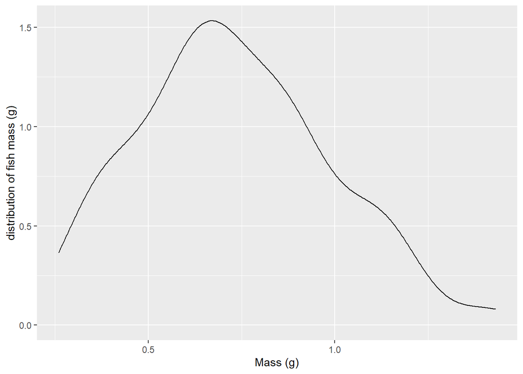

```r
(ggplot(CTmax_swim_Fry, aes(`Mass (g)`))
 +geom_density()
 +ylab("distribution of fish mass (g)"))
```

## *4. Explore the relationship between 2 variables*

I decided to look at the relationship between fork length and dropout time, as I’m curious to see if longer-bodied fish were able for a longer period of time; I chose to visualize this by using a scatter plot, to see if there are specific groupings that emerge.

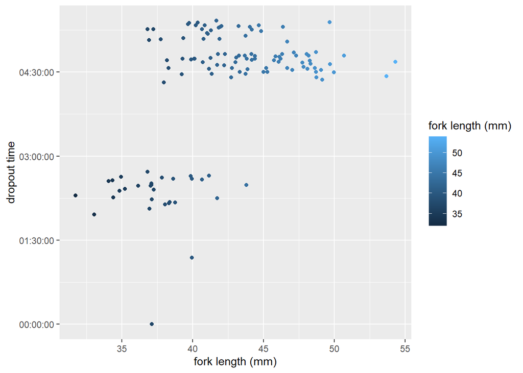

```r
(ggplot(CTmax_swim_Fry, aes(`fork length (mm)`, `dropout time`))+
   geom_jitter( aes(colour= `fork length (mm)`, width= 0.2)   ))
```

## *6. Use a boxplot to look at the frequency of different observations within a single variable*

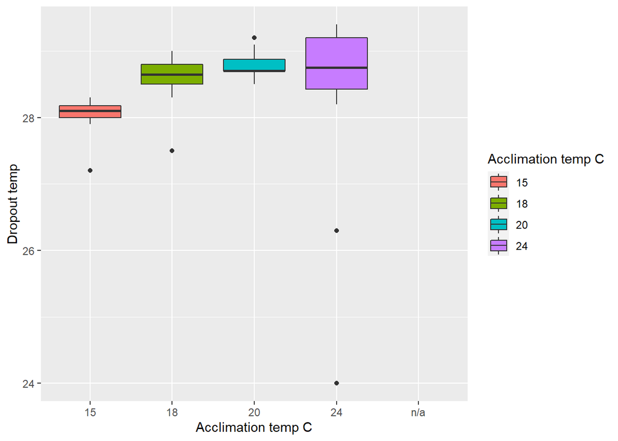

```r
(ggplot(CTmax_swim_Fry, aes(`Acclimation temp C`,`Dropout temp` ))

 + geom_boxplot( aes(fill=`Acclimation temp C` )))
```

## *8. Use a density plot to explore any of your variables*

Now I would like to compare body mass and acclimation temperature. Did the body mass of fish swimming vary greatly across acclimation temperatures? Body mass can be an approximation for muscle mass, and since all these fish are in the same age class, smaller bodied fish may have a disadvantage in swimming.

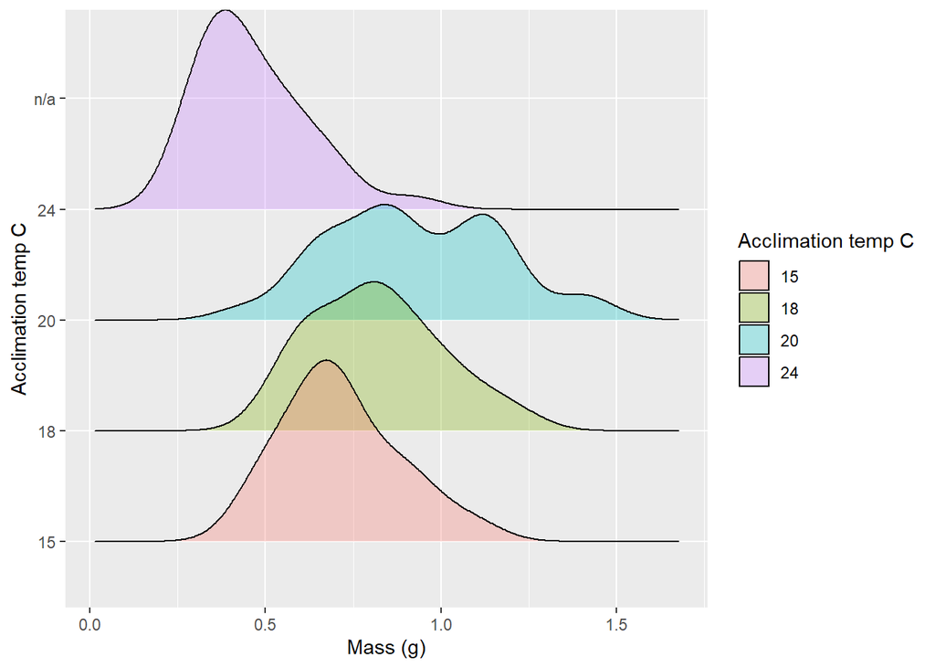

```r
(ggplot(CTmax_swim_Fry, aes(`Mass (g)`, `Acclimation temp C`))+
  ggridges::geom_density_ridges(aes(fill=`Acclimation temp C`), alpha=0.3))
```

# Task 3: Write your research questions

**1. Is body mass influenced by acclimation temperature?**

**2. Is there a relationship between fork length and body mass? I.e. can I predict that certain length fish will have a certain mass.**

**3. Can I find out if acclimation temperature has a more significant influence on either dropout time or dropout temperature?**

**4. Is there a relationship between body mass and dropout temperature?**